# IDS 435 - Optimization via Gurobi (Part 2)

##### Spring 2022

- A Procedure to Model an Optimization Problem in Gurobi
- A Toy Example
- Simple Linear Regression
- Feature Selection in Regression

### **A Procedure to Model an Optimization Problem in Gurobi**

The main task to use Gurobi in practice is to convert the mathematical formulation of an optimization problem into a Gurobi model that can be solved efficiently.

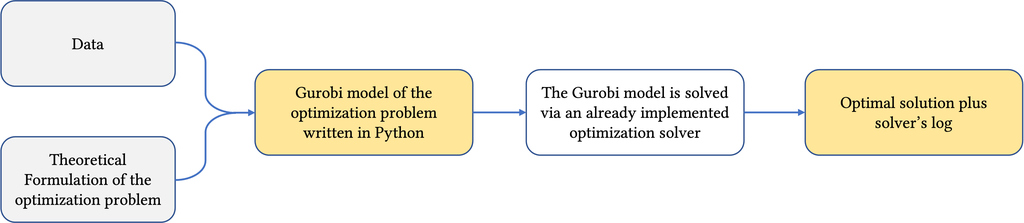

##### **The Procedure**

1. Sets and indices

   Use python `list`, `range`, `arrange`, etc to define index sets to count over decision variables and constraints.
1. Parameters (i.e., data)

   Data should be formatted in a way that is easy to define decision variables, objective function, and constraints in Gurobi. Data can be represented in different formats such as
   - Python lists
   - Python dictionaries
   - Numpy array
   - Pandas `dataframe`
   - Gurobi multidict Since Numpy arrays are widely-used data structures in python, we employ them to represent data that later on used in a Gurobi model
2. Decision variables
   - Specify type of the variable (real-valued, binary, integer, etc)
   - Specify if the variable is signed or not (positive or negative)
   - Try to define put related decision variables of the model in an array of variables instead of defining them individually

     ```
     # For loop
       for i in range (N):
               model.addVar( ... )

       # One line definition
       model.addMvar( shape=N)
     ```

3. Constraints
   - Specify type of a constraint (linear, quadratic, etc)
   - Find an appropriate Gurobi function to model the constraint (oftentimes you can use `addConstrs`)
   - Try to define multiple constraints in a single line of code via python inline for loop

     ```
     # For loop
       for i in range (N):
               model.addConstr( ... )

        # Inline for loop (preferred)
       model.addConstrs( ... for i in range (N))
     ```

4. Objective function
   - Define the objective function using data and decision variables
   - Specify if the problem is maximization or minimization
5. Optimize
   - Choose a solver
   - Specify parameters of the solver (i.e., stopping criteria, feasibility tolerance, etc)
   - Solve the Gurobi model
6. Analyze results (*Gurobi solved the model*)
   - Is model well-conditioned (i.e., no numerical issues encountered while optimization)?
   - Is the model "normalized"?
   - What is an optimal solution?
   - What is the optimal value?
   - How long did it take to solve the model?
7. Troubleshooting (*Gurobi could not solved the model*)
   - Is the issue with the numerical errors?
   - Is the issue with solver? Try a different optimization solver. Try to change the parameters of the solver (i.e., feasibility tolerance)?
   - Double-check the type of variables and their signs as well as the definition of constraints Gurobi model?

### **A Toy Example**

We use the following optimization problem to illustrate using Gurobi and aforementioned procedure for using Gurobi: $$ \begin{aligned} \min_{x_1,x_2} & \quad -x_1 - x_2\\ & \quad x_1 + 2x_2 \le 1\\ & \quad 2x_1 + x_2 \le 1\\ & \quad x_1,x_2\ge 0 \end{aligned} $$

```python
import gurobipy as gb
import numpy as np

if __name__ == "__main__":

    """         Step 1. Sets and indices            """
    num_var          = 2
    num_constr       = 2
    var_index        = range(num_var)
    constr_index     = range(num_constr)

    """         Step 2. Parameters                  """
    constr_matrix    = np.array([[1.,2.],
                                 [2.,1.]])
    rhs              = np.array([1.,1.])


    """         Step 3. Decision variables          """

    model           = gb.Model('Toy Example')
    x               = model.addMVar(
                                    shape    = num_var,
                                    name     = 'x',
                                    vtype    = gb.GRB.CONTINUOUS,
                                    lb       = 0.,
                                    ub       = gb.GRB.INFINITY )

    """         Step 4. Constraints                 """
    model.addConstrs(gb.quicksum(constr_matrix[i][j]*x[j]  for j in var_index) <= rhs[i]    for i in constr_index)

    """         Step 5. Objective function          """
    model.setObjective(-gb.quicksum(x))

    """         Step 6. Optimize                    """
    print('='*100)
    model.setParam('Method',2)
    model.setParam('Crossover',0)
    model.update()
    model.optimize()
    print('='*100)

    """         Step 7. Analyze results             """
    print('The optimal x_1:         \t',        x[0].X)
    print('The optimal x_2:         \t',        x[1].X)
    print('The optimal value is:    \t',        model.ObjVal)
    print('='*100)
```

```
Set parameter Username
Academic license - for non-commercial use only - expires 2022-05-07
====================================================================================================
Set parameter Method to value 2
Set parameter Crossover to value 0
Gurobi Optimizer version 9.5.1 build v9.5.1rc2 (mac64[rosetta2])
Thread count: 10 physical cores, 10 logical processors, using up to 10 threads
Optimize a model with 2 rows, 2 columns and 4 nonzeros
Model fingerprint: 0xed33d8fe
Coefficient statistics:
  Matrix range     [1e+00, 2e+00]
  Objective range  [1e+00, 1e+00]
  Bounds range     [0e+00, 0e+00]
  RHS range        [1e+00, 1e+00]
Presolve time: 0.00s
Presolved: 2 rows, 2 columns, 4 nonzeros
Ordering time: 0.00s

Barrier statistics:
 AA' NZ     : 1.000e+00
 Factor NZ  : 3.000e+00
 Factor Ops : 5.000e+00 (less than 1 second per iteration)
 Threads    : 1

                  Objective                Residual
Iter       Primal          Dual         Primal    Dual     Compl     Time
   0  -8.67927042e-01 -4.61538462e-01  1.51e-01 3.08e-01  2.86e-01     0s
   1  -6.05231787e-01 -6.96010401e-01  0.00e+00 0.00e+00  2.27e-02     0s
   2  -6.66536989e-01 -6.66799107e-01  0.00e+00 0.00e+00  6.55e-05     0s
   3  -6.66666537e-01 -6.66666799e-01  0.00e+00 0.00e+00  6.55e-08     0s
   4  -6.66666667e-01 -6.66666667e-01  0.00e+00 2.22e-16  6.55e-11     0s

Barrier solved model in 4 iterations and 0.01 seconds (0.00 work units)
Optimal objective -6.66666667e-01

====================================================================================================
The optimal x_1:         	 0.3333333332685205
The optimal x_2:         	 0.3333333332685205
The optimal value is:    	 -0.666666666537041
====================================================================================================
```

### **Simple Linear Regression**

This application is motivated by [curve fitting](https://www.gurobi.com/resource/curve-fitting-jupyter-notebook/) Gurobi example.

Consider a dataset of $N$ points $\{(x^i,y^i) : i=1,2,\dots,N\}$. We want to fit a linear model with intercept $\beta_0$ and slope $\beta_1$ to approximate response variable $y^i$ using feature $x^i$. Specifically, we want the following constraints to hold as close as possible: $$y^i \approx \beta_0 + \beta_1 x^i, \qquad \forall i=1,2,\dots,N.$$ For each $i$, $\beta_0 + \beta_1 x^i$ is the approximate value for $y_i$. Our objective is to compute $\beta_0$ and $\beta$ such that an "error" is minimized. Below we discuss two metrics of error and implement them in Gurobi.

1. Mean Absolute Deviation (MAD; *linear objective function*):

   $$ \begin{aligned} \min_{\beta_0,\beta_1} & \quad \frac{1}{N}\sum_{i=1}^N (u_i + v_i) \\ & \quad y^i = \beta_0 + \beta_1 x^i + u_i -v_i, &&\forall i=1,2,\dots,N, \\ & \quad u_i,v_i \ge0, &&\forall i=1,2,\dots,N,\\ & \quad \beta_0,\beta_1 \ \ \text{unrestricted}. \end{aligned} $$
2. Mean Squared Error (MSE; *quadratic objective function*):

   $$ \begin{aligned} \min_{\beta_0,\beta_1} & \quad \frac{1}{N}\sum_{i=1}^N \varepsilon^2_i \\ & \quad \varepsilon_i = y^i - \beta_0 - \beta_1 x^i, &&\forall i=1,2,\dots,N,\\ & \quad \varepsilon_i \ \ \text{unrestricted}, &&\forall i=1,2,\dots,N,\\ & \quad \beta_0,\beta_1 \ \ \text{unrestricted}. \end{aligned} $$

##### Gurobi model for MAD minimization

```
====================================================================================================
Gurobi Optimizer version 9.5.1 build v9.5.1rc2 (mac64[rosetta2])
Thread count: 10 physical cores, 10 logical processors, using up to 10 threads
Optimize a model with 10 rows, 22 columns and 39 nonzeros
Model fingerprint: 0x1a0d94ca
Coefficient statistics:
  Matrix range     [5e-01, 4e+00]
  Objective range  [1e+00, 1e+00]
  Bounds range     [0e+00, 0e+00]
  RHS range        [7e-01, 4e+00]
Presolve time: 0.00s
Presolved: 10 rows, 22 columns, 39 nonzeros

Iteration    Objective       Primal Inf.    Dual Inf.      Time
       0      handle free variables                          0s
      11    3.3900000e+00   0.000000e+00   0.000000e+00      0s

Solved in 11 iterations and 0.00 seconds (0.00 work units)
Optimal objective  3.390000000e+00
====================================================================================================
The optimal intercept:	 0.575
The optimal slope:    	 0.65
The optimal objective value: 	 3.3899999999999997
====================================================================================================
```

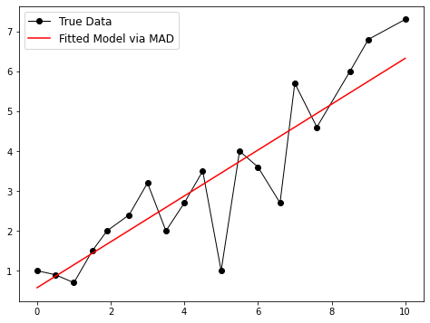

```python
import numpy as np
import gurobi as gb
import matplotlib.pyplot as plt
import warnings
warnings.filterwarnings('ignore')

if __name__ == "__main__":

    """         Step 1. Sets and indices            """
    num_data        = 10
    data_index      = range(num_data)

    """         Step 2. Parameters                  """
    x_train         = np.array([0.,  0.5,    1,      1.5,    1.9,    2.5,    3,      3.5,    4,
                                     4.5,    5.,  5.5,    6,      6.6,    7,      7.6,    8.5,    9,      10])

    y_train         = np.array([1.,  0.9,    .7,     1.5,    2.,     2.4,    3.2,    2,      2.7,
                                     3.5,    1.,  4,      3.6,    2.7,    5.7,    4.6,    6,      6.8,    7.3])

    """         Step 3. Decision Variables           """
    model           = gb.Model('MAD')

    ## coef := (\beta_0,\beta)
    coef            = model.addMVar(
                            shape    = 2,
                            vtype    = gb.GRB.CONTINUOUS,
                            lb       = -gb.GRB.INFINITY,
                            ub       =  gb.GRB.INFINITY )

    u               = model.addMVar(
                            shape    = num_data,
                            vtype    = gb.GRB.CONTINUOUS,
                            lb       = 0,
                            ub       = gb.GRB.INFINITY )

    v               = model.addMVar(
                            shape    = num_data,
                            vtype    = gb.GRB.CONTINUOUS,
                            lb       = 0,
                            ub       = gb.GRB.INFINITY )

    """         Step 4. Constraints                 """
    model.addConstrs(y_train[i] ==  coef[0] + coef[1]*x_train[i] + u[i] - v[i]  for i in data_index)

    """         Step 5. Objective function          """
    model.setObjective(gb.quicksum(u) + gb.quicksum(v))

    """         Step 6. Optimize                    """
    print('='*100)
    model.update()
    model.optimize()
    print('='*100)

    """         Step 7. Analyze results             """
    MAD_intercept, MAD_slope = coef[0].X,coef[1].X
    print('The optimal intercept:\t', MAD_intercept)
    print('The optimal slope:    \t', MAD_slope)
    print('The optimal objective value: \t', model.ObjVal)
    print('='*100)

    fig = plt.figure(figsize=(8,6))
    plt.plot(x_train,y_train,marker='o',lw=1,color='black',label='True Data')
    plt.plot(x_train,[MAD_intercept + x*MAD_intercept for x in x_train],color='red',label='Fitted Model via MAD')
    plt.legend(fontsize=12)
    plt.show()
```

##### Gurobi model for MSE minimization

```
====================================================================================================
Gurobi Optimizer version 9.5.1 build v9.5.1rc2 (mac64[rosetta2])
Thread count: 10 physical cores, 10 logical processors, using up to 10 threads
Optimize a model with 10 rows, 12 columns and 29 nonzeros
Model fingerprint: 0x2ce89fab
Model has 10 quadratic objective terms
Coefficient statistics:
  Matrix range     [5e-01, 4e+00]
  Objective range  [0e+00, 0e+00]
  QObjective range [2e+00, 2e+00]
  Bounds range     [0e+00, 0e+00]
  RHS range        [7e-01, 4e+00]
Presolve removed 1 rows and 1 columns
Presolve time: 0.00s
Presolved: 9 rows, 11 columns, 27 nonzeros
Presolved model has 10 quadratic objective terms
Ordering time: 0.00s

Barrier statistics:
 Free vars  : 11
 AA' NZ     : 3.600e+01
 Factor NZ  : 4.500e+01
 Factor Ops : 2.850e+02 (less than 1 second per iteration)
 Threads    : 1

                  Objective                Residual
Iter       Primal          Dual         Primal    Dual     Compl     Time
   0   1.78781526e+00 -1.78781526e+00  3.77e-15 7.83e-01  0.00e+00     0s
   1   1.78685941e+00  1.78685583e+00  1.13e-08 7.83e-07  0.00e+00     0s
   2   1.78685941e+00  1.78685941e+00  2.30e-14 7.82e-13  0.00e+00     0s

Barrier solved model in 2 iterations and 0.01 seconds (0.00 work units)
Optimal objective 1.78685941e+00

====================================================================================================
The optimal intercept:	 0.7149197447302484
The optimal slope:    	 0.5692322568168443
The optimal objective value: 	 1.7868594082382703
====================================================================================================
```

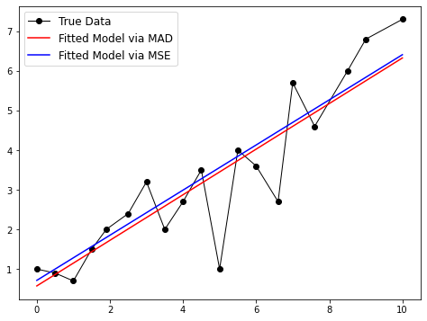

```python
import numpy as np
import gurobi as gb
import matplotlib.pyplot as plt

if __name__ == "__main__":



    """         Step 1. Sets and indices            """
    num_data        = 10
    data_index      = range(num_data)

    """         Step 2. Parameters                  """
    x_train         = np.array([0.,  0.5,    1,      1.5,    1.9,    2.5,    3,      3.5,    4,
                                     4.5,    5.,  5.5,    6,      6.6,    7,      7.6,    8.5,    9,      10])

    y_train         = np.array([1.,  0.9,    .7,     1.5,    2.,     2.4,    3.2,    2,      2.7,
                                     3.5,    1.,  4,      3.6,    2.7,    5.7,    4.6,    6,      6.8,    7.3])

    """         Step 3. Decision variables          """

    model           = gb.Model('MSE')

    ## coef := (\beta_0,\beta)
    coef            = model.addMVar(
                            shape    = 2,
                            vtype    = gb.GRB.CONTINUOUS,
                            lb       = -gb.GRB.INFINITY,
                            ub       =  gb.GRB.INFINITY )

    diff         = model.addMVar(
                            shape    = num_data,
                            vtype    = gb.GRB.CONTINUOUS,
                            lb       = -gb.GRB.INFINITY,
                            ub       = gb.GRB.INFINITY )

    """         Step 4. Constraints                 """
    model.addConstrs(diff[i] == y_train[i] - coef[0] - coef[1]*x_train[i]   for i in data_index)

    """         Step 5. Objective function          """
    model.setObjective(gb.quicksum(diff[i]*diff[i] for i in data_index))

    """         Step 6. Optimize                    """
    print('='*100)
    model.update()
    model.optimize()
    print('='*100)

    """         Step 7. Analyze results             """
    MSE_intercept, MSE_slope = coef[0].X,coef[1].X
    print('The optimal intercept:\t', MSE_intercept)
    print('The optimal slope:    \t', MSE_slope)
    print('The optimal objective value: \t', model.ObjVal)
    print('='*100)

    fig = plt.figure(figsize=(8,6))
    plt.plot(x_train,y_train,marker='o',lw=1,color='black',label='True Data')
    plt.plot(x_train,[MAD_intercept + x*MAD_intercept for x in x_train],color='red',label='Fitted Model via MAD')
    plt.plot(x_train,[MSE_intercept + x*MSE_slope for x in x_train],color='blue',label='Fitted Model via MSE')
    plt.legend(fontsize=12)
    plt.show()
```

### **Feature Selection in Regression**

This application is motivated by [Feature Selection for Forecasting](https://www.gurobi.com/resource/l0-regression/) Gurobi example.

##### Preliminaries

Building on the previous example, we study a linear regression problem in which the optimized linear model should only use a small subset of features. In other words, we need to select the best subset of features that their linear combinations have the lowest training error.

Consider training set $\{(x^i,y^i), i=1,2,\dots, N\}$ with $N$ observations, where $x^i=(x^i_1,x^i_2,\dots,x^i_d)$ and $y^i$ are $d$-dimensional feature vector and the value of the response variable associated with the $i$-th observation, respectively.

The goal in linear regression problem is to find coefficients $\beta=(\beta_0,\beta_1,\beta_2,\dots,\beta_d)$, where $\beta_0$ is the intercept and $(\beta_1,\beta_2,\dots,\beta_d)$ is the slope of the linear model, such that the following approximation errors attain their lowest values:

$$\varepsilon_i := y^i - \left(\beta_0 + \sum_{j=1}^d \beta_j x^i_j\right), \qquad \forall i=1,2,\dots,N.$$

**Ordinary least squares (OLS).** OLS is an optimization problem that allows us to obtain the lowest approximation error discussed above. OLS can be written as follows:

$$\tag{OLS} \min_{\beta} \ \mathrm{MSE}(\beta) $$

where

$$ \mathrm{MSE}(\beta) \ = \ \frac{1}{N} \sum_{i=1}^N \varepsilon^2_i \ = \ \frac{1}{N} \sum_{i=1}^N \left[ y^i - \left(\beta_0 + \sum_{j=1}^d \beta_j x^i_j\right) \right]^2 $$

**Indirect subset selection via LASSO regression.** OLS does not perform the subset selection, that is, allowing only $K$ out of $d+1$ elements of $\beta$ take a non-zero value. The LASSO regression is a modification of OLS to indirectly perform subset selection. It is given by the following optimization problem: $$\tag{LASSO} \min_{\beta} \ \mathrm{MSE}(\beta) \quad \text{ s.t. } \quad \sum_{j=0}^d |\beta_j|\le T. $$ LASSO is a convex optimization problem. LASSO does not guarantee that its optimal $\beta^*$ has at most $K$ non-zero elements. That is why we refer to it as an indirect approach for subset selection.

**Direct subset selection via $l_0$-regression.** To directly perform subset selection, we cannot stay in the convex optimization world since couting the number of non-zeros of a vector is not a convex function. The non-convex optimization problem that allows us to perfrom subset selection is given by the following $L_0$-regression problem: $$\tag{$l_0$-regression} \min_{\beta} \ \mathrm{MSE}(\beta) \quad \text{ s.t. } \quad \lVert \beta \rVert_0 \le K $$ where $$ \lVert \beta \rVert_0 := \mbox{number of non-zero elements of } \beta. $$

**Comparison of OLS, LASSO, and $l_0$-regression**

|  | OLS | LASSO | $l_0$-regression |
| --- | --- | --- | --- |
| Convex | Yes | Yes | No |
| Indirect subset selection | No | Yes | Yes |
| Direct subset selection | No | No | Yes |
| Constrained? | No | Yes | Yes |
| How to solve? | `LinearRegression` in sk-learn | `Lasso` in sk-learn | A model in Gurobi |

#### Reformulating $l_0$-regression

Let's focus on formulating $l_0$ constraint $\lVert \beta \rVert_0 \le K$. This constraint can be modeled using the followig constraints that are written via binary variables:

$$ \begin{aligned} & z_j := \begin{cases} 1 & \text{if } \beta_j \ne 0\\ 0 & \text{if } \beta_j = 0 \end{cases}, &&\quad \forall j=0,1,\dots,d;\\ & \sum_{j=0}^{d} z_j = K && \end{aligned} $$

Overall, we can reformulate $l_0$-regression problem as the following optimization problem with both continuous and integer variables: $$ \begin{aligned} \min_{\beta, z} & \ \frac{1}{N} \sum_{i=1}^N \left[ y^i - \left(\beta_0 + \sum_{j=1}^d \beta_j x^i_j\right) \right]^2\\ & \ z_j = 0, \quad \text{if } \quad \beta_j=0, && \forall j=0,1,\dots,d,\\ & \ z_j = 1, \quad \text{if } \quad \beta_j\ne 0, && \forall j=0,1,\dots,d,\\ & \ \sum_{j=0}^{d} z_j = K, &&\\ & \ \beta_j \ \ \text{ unrestricted}, && \forall j=0,1,\dots,d,\\ & \ z_j \ \ \text{ binary}, && \forall j=0,1,\dots,d.\\ \end{aligned} $$

```python
import numpy as np
import gurobi as gb

def MIQP_version_1(train_X:np.ndarray, train_y:np.ndarray, non_zero_budget:int):
    """         Step 1. Sets and indices            """
    num_data,dim    = np.shape(train_X)
    data_index      = range(num_data)     # 1,2, ..., N
    dim_index       = range(dim+1)        # 0,1, ..., d+1

    """         Step 2. Parameters                  """
    # Data comes from the input. Append a column of ones to the
    # feature matrix train_X to account for the intercept
    train_X         = np.concatenate([np.ones((num_data, 1)),train_X], axis=1)

    """         Step 3. Decision variables          """
    model           = gb.Model('MIQP')
    coef            = model.addMVar(
                            shape    = dim + 1,
                            vtype    = gb.GRB.CONTINUOUS,
                            lb       = -gb.GRB.INFINITY,
                            ub       =  gb.GRB.INFINITY )

    non_zero        = model.addMVar(
                            shape    = dim+1,
                            vtype    = gb.GRB.BINARY)


    """         Step 4. Constraints                 """

    for j in dim_index:
        model.addConstr((non_zero[j] == 0) >> (coef[j] == 0))

    model.addConstr(gb.quicksum(non_zero)<=non_zero_budget)


    """         Step 5. Objective function          """
    epsilon = [None for _ in data_index]
    for i in data_index:
        epsilon[i] = train_y[i]  - coef@train_X[i,:]


    model.setObjective((1/num_data)*gb.quicksum(epsilon[i]@epsilon[i] for i in data_index))


    """         Step 6. Optimize                    """
    model.setParam('Seed',       123)
    model.update()
    model.optimize()

    """         Step 7. Analyze results             """
    # we let the user to analyze the results and only return the optimal solution and value
    opt_coef = np.array([coef[j].X for j in dim_index])
    opt_val  = model.objVal
    return opt_coef, opt_val
```